# PPPR

PPPR Team

```r
library(vroom)
library(sf)
library(ggplot2)
library(ggmap)
library(kableExtra)
library(tidyverse)
library(data.table)
#remotes::install_github("CityOfPhiladelphia/rphl")
library(rphl)
library(lubridate)
library(furrr)
library(tidycensus)

ll <- function(dat, proj4 = 4326){st_transform(dat, proj4)}

root.dir = "https://raw.githubusercontent.com/urbanSpatial/Public-Policy-Analytics-Landing/master/DATA/"
source("https://raw.githubusercontent.com/urbanSpatial/Public-Policy-Analytics-Landing/master/functions.r")

#windowsFonts(font = windowsFont('Helvetica'))

crs = 'EPSG:2272'

plotTheme <- function(base_size = 9, title_size = 10){
  theme(
    text = element_text( color = "black"),
    plot.title = element_text(size = title_size, colour = "black", hjust = 0.5),
    plot.subtitle = element_text( face = 'italic',
                                 size = base_size, colour = "black", hjust = 0.5),
    plot.caption = element_text( hjust=0),
    axis.ticks = element_blank(),
    panel.background = element_blank(),
    panel.grid.major = element_line("grey80", size = 0.01),
    panel.grid.minor = element_blank(),
    panel.border = element_rect(colour = "black", fill=NA, size=.5),
    strip.background = element_blank(),
    strip.text = element_text( size=9),
    axis.title = element_text( size=9),
    axis.text = element_text( size=7),
    axis.text.y = element_text( size=7),
    plot.background = element_blank(),
    legend.background = element_blank(),
    legend.title = element_text( colour = "black", face = "italic", size = 9),
    legend.text = element_text( colour = "black", face = "italic", size = 7),
    strip.text.x = element_text( size = 9),
    legend.key.size = unit(.5, 'line')
  )
}

mapTheme <- function(base_size = 9, title_size = 10){
  theme(
    text = element_text( color = "black"),
    plot.title = element_text(size = title_size, colour = "black", hjust = 0.5),
    plot.subtitle = element_text( face = 'italic',
                                 size = base_size, colour = "black", hjust = 0.5),
    plot.caption = element_text( hjust=0),
    axis.ticks = element_blank(),
    panel.background = element_blank(),
    panel.grid.major = element_blank(),
    panel.grid.minor = element_blank(),
    panel.border = element_blank(),
    strip.background = element_blank(),
    strip.text = element_text(size=base_size),
    axis.title = element_text( size=9),
    axis.text = element_blank(),
    axis.text.y = element_blank(),
    plot.background = element_blank(),
    legend.background = element_blank(),
    legend.title = element_text( colour = "black", face = "italic", size = 9),
    legend.text = element_text( colour = "black", face = "italic", size = 7),
    strip.text.x = element_text(size=base_size),
    legend.key.size = unit(.5, 'line')
  )
}

palette5 <- c("#f9b294","#f2727f","#c06c86","#6d5c7e","#315d7f")
palette4 <- c("#f9b294","#f2727f","#c06c86","#6d5c7e")
palette2 <- c("#f9b294","#f2727f")
palette1_main <- "#F2727F"
palette1_assist <- '#F9B294'
```

```r
## NOTE: You will need to create secrets.json, using the template
## to enter private credentials for interacting with the database

get_secrets <- function() {
  path <- "secrets/secrets.json"
  if (!file.exists(path)) {
    stop("Can't find secret file: '", path, "'")
  }

  jsonlite::read_json(path)
}
secrets <- get_secrets()

# database settings
dbname = secrets$db_name
host = secrets$db_host
port = secrets$db_port
username =  secrets$db_username
password = secrets$db_password
census_api_key(secrets$census_api_key, install=TRUE, overwrite=TRUE)
```

```
## Your original .Renviron will be backed up and stored in your R HOME directory if needed.
```

```
## Your API key has been stored in your .Renviron and can be accessed by Sys.getenv("CENSUS_API_KEY").
## To use now, restart R or run `readRenviron("~/.Renviron")`
```

```
## [1] "41e1c0d912341017fa6f36a5da061d3b23de335e"
```

### Data Loading

#### Folder: OneDrive-2021-12-07

```r
# moves2018 <- vroom("data/OneDrive-2021-12-07/moves_2018.csv")
# colnames(moves2018)
```

```r
# moves_monthly2020 <- vroom("data/OneDrive-2021-12-07/moves_monthly2020.csv")
# colnames(moves_monthly2020)
```

The above two data are from 2018 and 2020. Based on the SOP, we only used the data of 2021. **Therefore, these two files should not be used.**

#### Folder: safegraph

```r
brand_info <- vroom("data/safegraph/Philadelphia-Camden-WilmingtonPA-NJ-DE-MDMSA-CORE_POI-2021_11-2021-12-17/brand_info.csv")
#colnames(brand_info)

kable(head(brand_info,3),align = 'c',caption = '<center>Table 1. brand_info of SafeGraph data <center/>')%>%
  kable_classic(full_width = F)%>%
  kable_styling(position = "center")%>%
  scroll_box(width = "100%", height = "400px")
```

Table 1. brand_info of SafeGraph data

| safegraph_brand_id | brand_name | parent_safegraph_brand_id | naics_code | top_category | sub_category | stock_symbol | stock_exchange | iso_country_codes_open | iso_country_codes_closed |
| --- | --- | --- | --- | --- | --- | --- | --- | --- | --- |
| SG_BRAND_1ec16189589a76ef | & Other Stories | NA | 448120 | Clothing Stores | Women’s Clothing Stores | NA | NA | [“US”] | [“US”] |
| SG_BRAND_12b20c8402b220acfe0e65dd113dbbc7 | &pizza | NA | 722511 | Restaurants and Other Eating Places | Full-Service Restaurants | NA | NA | [“US”] | [] |
| SG_BRAND_6462594f4a598a94 | 1 Hotels | NA | 721110 | Traveler Accommodation | Hotels (except Casino Hotels) and Motels | NA | NA | [“US”,“CA”,“CN”] | [] |

```r
core_poi <- vroom("data/safegraph/Philadelphia-Camden-WilmingtonPA-NJ-DE-MDMSA-CORE_POI-2021_11-2021-12-17/core_poi.csv")
#colnames(core_poi)

kable(head(core_poi,3),align = 'c',caption = '<center>Table 2. core_poi of SafeGraph data <center/>')%>%
  kable_classic(full_width = F)%>%
  kable_styling(position = "center")%>%
  scroll_box(width = "100%", height = "400px")
```

Table 2. core_poi of SafeGraph data

| placekey | parent_placekey | location_name | safegraph_brand_ids | brands | top_category | sub_category | naics_code | latitude | longitude | street_address | city | region | postal_code | iso_country_code | phone_number | open_hours | category_tags | opened_on | closed_on | tracking_closed_since | geometry_type |
| --- | --- | --- | --- | --- | --- | --- | --- | --- | --- | --- | --- | --- | --- | --- | --- | --- | --- | --- | --- | --- | --- |
| 226-222@628-ctb-wkz | NA | Highpoint Pediatric Dental Associates | NA | NA | Offices of Dentists | Offices of Dentists | 621210 | 40.26209 | -75.22003 | 1600 Horizon Dr Ste 101 | Brittany Farms-The Highlands | PA | 18914 | US | 12158224042 | { “Mon”: [[“8:30”, “19:00”]], “Tue”: [[“8:30”, “17:00”]], “Wed”: [[“8:30”, “17:00”]], “Thu”: [[“8:30”, “18:00”]], “Fri”: [], “Sat”: [], “Sun”: [] } | NA | NA | NA | 2019-07 | POLYGON |
| 229-222@63s-cc7-pgk | NA | Uncommon Ramen | NA | NA | Restaurants and Other Eating Places | Full-Service Restaurants | 722511 | 40.13394 | -75.51799 | 239 Bridge St | Phoenixville | PA | 19460 | US | 14849280468 | { “Mon”: [], “Tue”: [], “Wed”: [], “Thu”: [[“17:00”, “21:00”]], “Fri”: [[“17:00”, “22:00”]], “Sat”: [[“17:00”, “22:00”]], “Sun”: [[“17:00”, “21:00”]] } | Japanese Food | NA | NA | 2019-07 | POLYGON |
| 222-225@63s-f2y-k4v | zzw-222@63s-f2y-gtv | Target | SG_BRAND_42aefbae01d2dfd981f7da7d823d689e | Target | Department Stores | Department Stores | 452210 | 39.88076 | -75.52748 | 600 Hatton Dr | Glen Mills | PA | 19342 | US | NA | { “Mon”: [[“8:00”, “22:00”]], “Tue”: [[“8:00”, “22:00”]], “Wed”: [[“8:00”, “22:00”]], “Thu”: [[“8:00”, “22:00”]], “Fri”: [[“8:00”, “22:00”]], “Sat”: [[“8:00”, “22:00”]], “Sun”: [[“8:00”, “22:00”]] } | NA | 2019-10 | NA | 2019-07 | POLYGON |

**These two datasets (‘brand_info’ and ‘core_poi’ from safegraph) are dictionary data.**

```r
#HPS = home_panel_summary
#NS = normalization_stats
#VPS = visit_panel_summary

monthList = c("01","02","03","04","05","06","07","08","09","10","11")

# home_panel_summary
hpsAllMonth = data.frame()

for (i in monthList){
  currentMonth = vroom(paste("data/safegraph/SafeGraph Data Purchase Dec-16-2021/Philadelphia-Camden-WilmingtonPA-NJ-DE-MDMSA-PATTERNS-2021_",
       i,
       "-2021-12-17/home_panel_summary.csv",sep = ""))%>%
    filter(region=="pa")
  hpsAllMonth = rbind(hpsAllMonth,currentMonth)
  #print(paste("Current input home_panel_summary dataframe is in ",i," month",sep = ""))
}

kable(head(hpsAllMonth,3),align = 'c',caption = '<center>Table 3. home pannel summary of 2021 whole year in SafeGraph data <center/>')%>%
  kable_classic(full_width = F)%>%
  kable_styling(position = "center")%>%
  scroll_box(width = "100%", height = "400px")
```

Table 3. home pannel summary of 2021 whole year in SafeGraph data

| year | month | region | iso_country_code | census_block_group | number_devices_residing | number_devices_primary_daytime |
| --- | --- | --- | --- | --- | --- | --- |
| 2021 | 1 | pa | US | 420710113003 | 61 | 58 |
| 2021 | 1 | pa | US | 420912034031 | 60 | 59 |
| 2021 | 1 | pa | US | 421010245004 | 32 | 23 |

```r
# normalization_Stats
nsAllMonth = data.frame()

for (i in monthList){
  currentMonth = vroom(paste("data/safegraph/SafeGraph Data Purchase Dec-16-2021/Philadelphia-Camden-WilmingtonPA-NJ-DE-MDMSA-PATTERNS-2021_",
       i,
       "-2021-12-17/normalization_stats.csv",sep = ""))%>%
    filter(region=="pa")
  nsAllMonth = rbind(nsAllMonth,currentMonth)
  #print(paste("Current input normalization_stats dataframe is in ",i," month",sep = ""))
}

kable(head(nsAllMonth,3),align = 'c',caption = '<center>Table 4. normalization stats of 2021 whole year in SafeGraph data <center/>')%>%
  kable_classic(full_width = F)%>%
  kable_styling(position = "center")%>%
  scroll_box(width = "100%", height = "400px")
```

Table 4. normalization stats of 2021 whole year in SafeGraph data

| year | month | day | region | iso_country_code | total_visits | total_devices_seen | total_home_visits | total_home_visitors |
| --- | --- | --- | --- | --- | --- | --- | --- | --- |
| 2021 | 1 | 1 | pa | US | 1198757 | 647557 | 693616 | 479707 |
| 2021 | 1 | 2 | pa | US | 1583461 | 671762 | 740901 | 483571 |
| 2021 | 1 | 3 | pa | US | 1307077 | 657556 | 718342 | 495958 |

```r
# visit_panel_summary
vpsAllMonth = data.frame()

for (i in monthList){
  currentMonth = vroom(paste("data/safegraph/SafeGraph Data Purchase Dec-16-2021/Philadelphia-Camden-WilmingtonPA-NJ-DE-MDMSA-PATTERNS-2021_",
       i,
       "-2021-12-17/visit_panel_summary.csv",sep = ""))%>%
    filter(region=="pa")
  vpsAllMonth = rbind(vpsAllMonth,currentMonth)
  #print(paste("Current input visit_panel_summary dataframe is in ",i," month",sep = ""))
}

kable(head(vpsAllMonth,3),align = 'c',caption = '<center>Table 5. visit panel summary of 2021 whole year in SafeGraph data <center/>')%>%
  kable_classic(full_width = F)%>%
  kable_styling(position = "center")%>%
  scroll_box(width = "100%", height = "400px")
```

Table 5. visit panel summary of 2021 whole year in SafeGraph data

| year | month | region | num_visits | num_unique_visitors |
| --- | --- | --- | --- | --- |
| 2021 | 1 | pa | 25127309 | 2001697 |
| 2021 | 2 | pa | 23145093 | 1707911 |
| 2021 | 3 | pa | 29635248 | 1774731 |

```r
# Pattern
patternAllMonth = data.frame()

for (i in monthList){
  currentMonth = vroom(paste("data/safegraph/SafeGraph Data Purchase Dec-16-2021/Philadelphia-Camden-WilmingtonPA-NJ-DE-MDMSA-PATTERNS-2021_",
       i,
       "-2021-12-17/patterns.csv.gz",sep = ""))%>%
    filter(region=="PA")%>%
    mutate(month=paste(i,sep = ""))
  patternAllMonth = rbind(patternAllMonth,currentMonth)
  #print(paste("Current input patterns dataframe is in ",i," month",sep = ""))
}

kable(head(patternAllMonth,3),align = 'c',caption = '<center>Table 6. patterns of 2021 whole year in SafeGraph data <center/>')%>%
  kable_classic(full_width = F)%>%
  kable_styling(position = "center")%>%
  scroll_box(width = "100%", height = "400px")
```

Table 6. patterns of 2021 whole year in SafeGraph data

| placekey | parent_placekey | location_name | street_address | city | region | postal_code | safegraph_brand_ids | brands | date_range_start | date_range_end | raw_visit_counts | raw_visitor_counts | visits_by_day | poi_cbg | visitor_home_cbgs | visitor_home_aggregation | visitor_daytime_cbgs | visitor_country_of_origin | distance_from_home | median_dwell | bucketed_dwell_times | related_same_day_brand | related_same_month_brand | popularity_by_hour | popularity_by_day | device_type | month |
| --- | --- | --- | --- | --- | --- | --- | --- | --- | --- | --- | --- | --- | --- | --- | --- | --- | --- | --- | --- | --- | --- | --- | --- | --- | --- | --- | --- |
| zzw-223@628-pm5-2hq | NA | Vellum and Twine | 1241 Carpenter St Studio 309 | Philadelphia | PA | 19147 | NA | NA | 2021-01-01 05:00:00 | 2021-02-01 05:00:00 | 82 | 51 | [1,3,3,6,5,3,3,7,0,3,3,0,1,0,3,0,3,0,1,3,3,3,10,3,3,2,5,2,0,1,2] | 421010024005 | {“421010024005”:4,“421010267004”:4,“420171003032”:4,“340076010002”:4,“420912001041”:4,“420293039021”:4} | {“42101002400”:5,“42045401600”:5,“42101013900”:4,“42029303902”:4,“42091206905”:4,“42101015800”:4,“34015501102”:4,“42091200104”:4,“42101002900”:4,“42101001300”:4,“42101001101”:4,“42101004102”:4} | {“420171003032”:4,“421010041021”:4,“340057005033”:4} | {“US”:40} | 9064 | 43.5 | {“<5”:2,“5-10”:25,“11-20”:8,“21-60”:10,“61-120”:7,“121-240”:9,“>240”:21} | {“Popeyes Louisiana Kitchen”:4,“Wawa”:4,“Dunkin’”:4,“Restaurant Depot”:3,“Walgreens”:3,“Jackson Hewitt Tax Service”:3,“Sunoco”:3,“P.C. Richard & Son”:1,“Jimmy John’s”:1,“Romp & Roll”:1,“Tesla Motors”:… | {“The Home Depot”:29,“Wawa”:29,“Dunkin’”:25,“Target”:24,“Lowe’s”:22,“Walmart”:20,“Rite Aid”:18,“CVS”:18,“Sunoco”:18,“Dollar Tree”:18,“Dollar General”:16,“Walgreens”:16,“McDonald’s”:16,“ShopRite”:16,“S… | [7,6,7,7,7,7,8,15,11,15,19,22,25,26,27,23,21,18,13,7,6,9,7,8] | {“Monday”:12,“Tuesday”:8,“Wednesday”:12,“Thursday”:8,“Friday”:14,“Saturday”:14,“Sunday”:14} | {“android”:18,“ios”:29} | 01 |
| 225-222@628-crg-vpv | NA | Perkasie PC Repair & Recycling | 1133 N 5th St | Perkasie | PA | 18944 | NA | NA | 2021-01-01 05:00:00 | 2021-02-01 05:00:00 | 55 | 27 | [2,3,1,2,3,2,2,2,0,0,4,1,2,4,2,0,2,2,0,2,2,1,2,1,3,3,4,2,1,0,0] | 420171023001 | {“420171024011”:4,“420171024012”:4,“420171024022”:4,“420171031032”:4,“420171023001”:4,“420171040001”:4,“420171021041”:4,“420912078001”:4} | {“42017102401”:8,“42017104000”:4,“42017102402”:4,“42091207800”:4} | {“420171023001”:4,“420171024022”:4,“420171040001”:4,“420171024012”:4} | {“US”:29} | 4132 | 41.0 | {“<5”:2,“5-10”:9,“11-20”:6,“21-60”:19,“61-120”:18,“121-240”:1,“>240”:0} | {“Simon mall”:15,“Dunkin’”:11,“Walmart”:6,“Wawa”:6,“Target”:4,“Domino’s Pizza”:4,“Taco Bell”:4,“The Home Depot”:4,“Chick-fil-A”:4,“CVS”:4,“Petco”:2,“PrimoHoagies”:2,“Little Caesars”:2,“Philly Pretzel … | {“Wawa”:70,“Walmart”:52,“Giant Food Stores”:41,“McDonald’s”:41,“CVS”:33,“Simon mall”:26,“Lowe’s”:26,“Dunkin’”:26,“Starbucks”:22,“Target”:19,“Domino’s Pizza”:19,“Kohl’s”:19,“Costco”:19,“Dick’s Sporting… | [0,0,0,0,0,0,0,0,6,10,3,3,2,1,3,14,20,18,9,3,1,0,0,0] | {“Monday”:11,“Tuesday”:7,“Wednesday”:10,“Thursday”:10,“Friday”:8,“Saturday”:5,“Sunday”:4} | {“android”:18,“ios”:16} | 01 |
| zzy-222@63s-cxf-nt9 | NA | Rehab & Pain Center | 3118 Main St | Sumneytown | PA | 18084 | NA | NA | 2021-01-01 05:00:00 | 2021-02-01 05:00:00 | 1 | 1 | [0,0,0,0,0,0,1,0,0,0,0,0,0,0,0,0,0,0,0,0,0,0,0,0,0,0,0,0,0,0,0] | 420912076002 | {} | {} | {} | NA | NA | 24.0 | {“<5”:0,“5-10”:0,“11-20”:0,“21-60”:1,“61-120”:0,“121-240”:0,“>240”:0} | {} | {} | [0,0,0,0,0,0,0,0,0,0,0,0,0,1,0,0,0,0,0,0,0,0,0,0] | {“Monday”:0,“Tuesday”:0,“Wednesday”:0,“Thursday”:1,“Friday”:0,“Saturday”:0,“Sunday”:0} | {“android”:0,“ios”:0} | 01 |

#### Folder: OpenDataPhilly

**Relevant data of PPR finder**

[figure not shown]

Figure 1. Locations of pprDistrict

```r
philly <- st_read("https://opendata.arcgis.com/datasets/405ec3da942d4e20869d4e1449a2be48_0.geojson")

pprDistrict <- st_read('https://opendata.arcgis.com/datasets/0cdc4a1e86c6463b9600f9d9fca39875_0.geojson') %>%
  st_transform(crs)

destDistrict <- pprDistrict %>% filter(DISTRICTID %in% c(7,8,9))

base_map <- get_map(location = unname(st_bbox(ll(st_buffer(st_union(pprDistrict),11000)))),maptype = "terrian")

ggmap(base_map) +
  geom_sf(data=ll(st_union(pprDistrict)),color="black",size=2,fill = "transparent",inherit.aes = FALSE)+
  geom_sf(data=ll(pprDistrict),color='black',size=2,fill = "transparent",inherit.aes = FALSE)+
  geom_sf(data=ll(destDistrict),color=palette1_main,size=2,fill = "transparent",inherit.aes = FALSE)+
  labs(title = "",
       subtitle = "",
       x="",y="")+
  mapTheme()
```

The whole Philadelphia is divided into 10 PPR districts, and the project mainly focus on the District 7、8、9 as pilot project which are highlighted in the map using the color red.

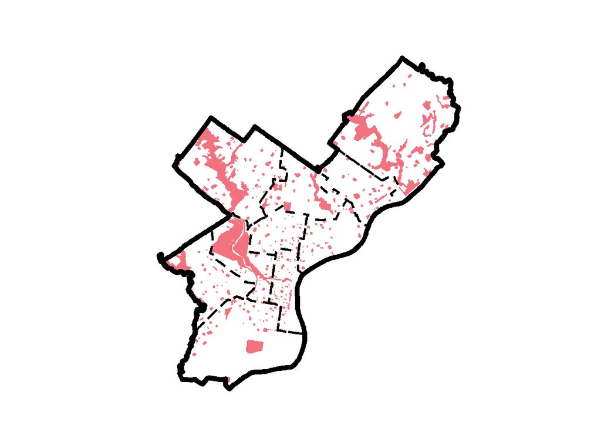

Figure 2. Locations of pprProperties

```r
pprProperties <- st_read('https://opendata.arcgis.com/datasets/d52445160ab14380a673e5849203eb64_0.geojson')%>%
  st_transform(crs)

ggplot() +
  geom_sf(data=pprProperties,color=palette1_main,fill = palette1_main)+
  geom_sf(data=st_union(pprDistrict),color="black",size=2,fill = "transparent")+
  geom_sf(data=pprDistrict,color="black",size=1,linetype ="dashed",fill = "transparent")+
  labs(title = "",
       subtitle = "",
       x="",y="")+
  mapTheme()
```

```r
pprOutPrograms <- st_read('https://opendata.arcgis.com/datasets/1f5d8108e06d457783538d4b7808c246_0.geojson')%>%
  st_transform(crs)

# ggplot() +
#   geom_sf(data=pprOutPrograms,color=palette1_main,size=8,fill = palette1_main)+
#   geom_sf(data=st_union(pprDistrict),color="black",size=2,fill = "transparent")+
#   geom_sf(data=pprDistrict,color="black",size=1,linetype ="dashed",fill = "transparent")+
#   labs(title = "",
#        subtitle = "",
#        x="",y="")+
#   mapTheme()
```

```r
pprPicnicSites <- st_read('https://phl.carto.com/api/v2/sql?q=SELECT+*+FROM+ppr_picnic_sites&filename=ppr_picnic_sites&format=geojson&skipfields=cartodb_id')%>%
  st_transform(crs)

# ggplot() +
#   geom_sf(data=pprPicnicSites,color=palette1_main,fill = palette1_main)+
#   geom_sf(data=st_union(pprDistrict),color="black",size=2,fill = "transparent")+
#   geom_sf(data=pprDistrict,color="black",size=1,linetype ="dashed",fill = "transparent")+
#   labs(title = "",
#        subtitle = "",
#        x="",y="")+
#   mapTheme()
```

```r
pprAdExercise <- st_read('https://phl.carto.com/api/v2/sql?q=SELECT+*+FROM+ppr_adult_exercise_equipment&filename=ppr_adult_exercise_equipment&format=geojson&skipfields=cartodb_id')%>%
  st_transform(crs)

# ggplot() +
#   geom_sf(data=pprAdExercise,color=palette1_main,fill = palette1_main)+
#   geom_sf(data=st_union(pprDistrict),color="black",size=2,fill = "transparent")+
#   geom_sf(data=pprDistrict,color="black",size=1,linetype ="dashed",fill = "transparent")+
#   labs(title = "",
#        subtitle = "",
#        x="",y="")+
#   mapTheme()
```

```r
pprSwimmingPool <- st_read('https://opendata.arcgis.com/datasets/c6f6176968f04d3f88adbc4c362af55d_0.geojson')%>%
  st_transform(crs)

# ggplot() +
#   geom_sf(data=pprSwimmingPool,color=palette1_main,fill = palette1_main)+
#   geom_sf(data=st_union(pprDistrict),color="black",size=2,fill = "transparent")+
#   geom_sf(data=pprDistrict,color="black",size=1,linetype ="dashed",fill = "transparent")+
#   labs(title = "",
#        subtitle = "",
#        x="",y="")+
#   mapTheme()
```

```r
pprTennisCourt <- st_read('https://phl.carto.com/api/v2/sql?q=SELECT+*+FROM+ppr_tennis_courts&filename=ppr_tennis_courts&format=geojson&skipfields=cartodb_id')%>%
  st_transform(crs)

# ggplot() +
#   geom_sf(data=pprTennisCourt,color=palette1_main,fill = palette1_main)+
#   geom_sf(data=st_union(pprDistrict),color="black",size=2,fill = "transparent")+
#   geom_sf(data=pprDistrict,color="black",size=1,linetype ="dashed",fill = "transparent")+
#   labs(title = "",
#        subtitle = "",
#        x="",y="")+
#   mapTheme()
```

```r
pprSpraygrounds <- st_read('https://opendata.arcgis.com/datasets/a148cc904d374b22bd456e44a044d554_0.geojson')%>%
  st_transform(crs)

# ggplot() +
#   geom_sf(data=pprSpraygrounds,color=palette1_main)+
#   geom_sf(data=st_union(pprDistrict),color="black",size=2,fill = "transparent")+
#   geom_sf(data=pprDistrict,color="black",size=1,linetype ="dashed",fill = "transparent")+
#   labs(title = "",
#        subtitle = "",
#        x="",y="")+
#   mapTheme()
```

```r
pprHydrationStations <- st_read('https://opendata.arcgis.com/datasets/cc35dc98180249fb9a6f2f5f06657df1_0.geojson')%>%
  st_transform(crs)

# ggplot() +
#   geom_sf(data=pprHydrationStations,color=palette1_main,fill = palette1_main)+
#   geom_sf(data=st_union(pprDistrict),color="black",size=2,fill = "transparent")+
#   geom_sf(data=pprDistrict,color="black",size=1,linetype ="dashed",fill = "transparent")+
#   labs(title = "",
#        subtitle = "",
#        x="",y="")+
#   mapTheme()
```

```r
pprPlaygrounds <- st_read('https://opendata.arcgis.com/datasets/899c807e205244278b3f39421be8489c_0.geojson')%>%
  st_transform(crs)

# ggplot() +
#   geom_sf(data=pprPlaygrounds,color=palette1_main,fill = palette1_main)+
#   geom_sf(data=st_union(pprDistrict),color="black",size=2,fill = "transparent")+
#   geom_sf(data=pprDistrict,color="black",size=1,linetype ="dashed",fill = "transparent")+
#   labs(title = "",
#        subtitle = "",
#        x="",y="")+
#   mapTheme()
```

```r
pprBoatLaunches <- st_read('https://opendata.arcgis.com/api/v3/datasets/ba32e1ac9c5341e1916274c2df3fbe22_0/downloads/data?format=geojson&spatialRefId=4326')%>%
  st_transform(crs)

# ggplot() +
#   geom_sf(data=pprBoatLaunches,color=palette1_main,fill = palette1_main)+
#   geom_sf(data=st_union(pprDistrict),color="black",size=2,fill = "transparent")+
#   geom_sf(data=pprDistrict,color="black",size=1,linetype ="dashed",fill = "transparent")+
#   labs(title = "",
#        subtitle = "",
#        x="",y="")+
#   mapTheme()
```

```r
pprBuildingStructures <- st_read('https://opendata.arcgis.com/datasets/97e90a049a35453ba0c51f974b3c77b4_0.geojson')%>%
  st_transform(crs)

# ggplot() +
#   geom_sf(data=pprBuildingStructures,color=palette1_main,size=1,fill = palette1_main)+
#   geom_sf(data=st_union(pprDistrict),color="black",size=2,fill = "transparent")+
#   geom_sf(data=pprDistrict,color="black",size=1,linetype ="dashed",fill = "transparent")+
#   labs(title = "",
#        subtitle = "",
#        x="",y="")+
#   mapTheme()
```

```r
query <- paste("SELECT objectid, avg_height, shape_area",
               "FROM ppr_tree_canopy_outlines_2015",
               "ORDER BY objectid ASC")

pprTreeCanopyWithArea <- get_carto(query, format = "csv",
  base_url = "https://phl.carto.com/api/v2/sql", stringsAsFactors = F)


pprTreeCanopy <- st_read('https://phl.carto.com/api/v2/sql?q=SELECT+*+FROM+ppr_tree_canopy_points_2015&filename=ppr_tree_canopy_points_2015&format=geojson&skipfields=cartodb_id')%>%
  st_transform(crs)%>%
  left_join(pprTreeCanopyWithArea,by = "objectid")

# ggplot() +
#   geom_sf(data=pprTreeCanopy,color=palette1_main,aes(size=shape_area),fill = palette1_main)+
#   geom_sf(data=st_union(pprDistrict),color="black",size=2,fill = "transparent")+
#   geom_sf(data=pprDistrict,color="black",size=1,linetype ="dashed",fill = "transparent")+
#   labs(title = "",
#        subtitle = "",
#        x="",y="")+
#   mapTheme()
```

```r
pprPermittableSpace <- st_read('https://opendata.arcgis.com/datasets/811b67c999bd4e839abb68b16c16f623_0.geojson')%>%
  st_transform(crs)

# ggplot() +
#   geom_sf(data=pprPermittableSpace,color=palette1_main,fill = palette1_main)+
#   geom_sf(data=st_union(pprDistrict),color="black",size=2,fill = "transparent")+
#   geom_sf(data=pprDistrict,color="black",size=1,linetype ="dashed",fill = "transparent")+
#   labs(title = "",
#        subtitle = "",
#        x="",y="")+
#   mapTheme()
```

And there are other datasets from the PPR finder unused right now. They are datasets about the number and quality of facilities of PPR.

#### Folder: FromPPR

These are datasets directly from PPR officers. These datasets are highly related to our project.

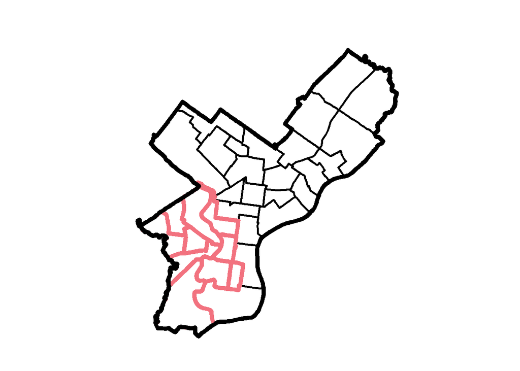

Figure 15. Locations of pprServiceArea

```r
library(rgdal)
pprServiceArea <- read_sf(dsn="data/FromPPR/PPR_Service_Areas_2021/PPR_Service_Areas_2021.shp")%>%
  st_transform(crs = crs)

pprDestServiceArea <- pprServiceArea %>% filter(PPR_DIST %in% c(7,8,9))

ggplot() +
  geom_sf(data=pprServiceArea,color='black',size=1,fill = "transparent")+
  geom_sf(data=pprDestServiceArea,color=palette1_main,size=2,fill = "transparent")+
  geom_sf(data=st_union(pprDistrict),color="black",size=2,fill = "transparent")+
  labs(title = "",
       subtitle = "",
       x="",y="")+
  mapTheme()
```

The above map is about service areas. Each district unit is divided into several service area units for the sake of administration. The pink lines in the map are the services areas in District 7,8,9. These service areas are the target of this project. About the navy yard, whether it should be included into district 9?

```r
program2021 <- vroom("data/FromPPR/PPR-programs-attended-2021-with-schedules.csv")
kable(head(program2021,3),align = 'c',caption = '<center>Table 8. Program information of PPR Programs data <center/>')%>%
  kable_classic(full_width = F)%>%
  kable_styling(position = "center")%>%
  scroll_box(width = "100%", height = "400px")
```

Table 8. Program information of PPR Programs data

| FacilityID | Facility | ProgramID | ActvityTypeCategory | ActivityType | Gender | AgeLow | AgeHigh | AttendanceWeekDate | RegisteredIndividualsCount | UniqueIndividualCount | ProgramScheduleID | DateFrom | DateTo | Days | TimeFrom | TimeTo |
| --- | --- | --- | --- | --- | --- | --- | --- | --- | --- | --- | --- | --- | --- | --- | --- | --- |
| {C8420FF3-289F-4737-A4F5-FF44DE89CA58} | McVeigh Recreation Center | 300 | After School | After School | M/F | 6 | 12 | 12/27/2021 | 21 | 0 | 8348 | 9/13/2021 | 5/27/2022 | Monday Tuesday Wednesday Thursday Friday | 15:00:00 | 18:00:00 |
| {DA9F8E3A-D19A-46DD-9040-5ACE360CDD2A} | Kendrick Recreation Center | 4800 | Athletic | Gymnastics / Tumbling | M/F | 3 | 5 | 12/13/2021 | 12 | 12 | 8883 | 12/6/2021 | 2/26/2022 | Thursday | 17:30:00 | 18:30:00 |
| {DA9F8E3A-D19A-46DD-9040-5ACE360CDD2A} | Kendrick Recreation Center | 4800 | Athletic | Gymnastics / Tumbling | M/F | 3 | 5 | 12/13/2021 | 12 | 12 | 8504 | 9/16/2021 | 11/18/2021 | Thursday | 17:30:00 | 18:30:00 |

The above dataset gives information about PPR programs in 2021, including information like the duration of the program, the attendence of the program etc. But some wrangling are needed for further uses. And the wrangling is taken in the next section.

```r
propertyArea <- read.csv("data/FromPPR/Service_Area_Sites.csv")
```

The above dataset has information about each property inside the service area. This dataset can be joined to **pprServiceArea** using the service area id.

```r
facilityID <- read.csv("data/FromPPR/tblFacility_to_PPR_Properties.csv")
```

The above dataset is offered as dictionary data to provide links between facility id and PPR property object id. ({003695FA-5CC6-4572-9916-799609577319} - 209)

### Data Wrangling

#### Property data

```r
# replace "and" with "&"
pprProperties <- pprProperties %>%
  mutate(OFFICIAL_NAME = gsub("and", "&", pprProperties$OFFICIAL_NAME),
         PUBLIC_NAME = gsub("and", "&", pprProperties$PUBLIC_NAME))


# join method 1
property.join1 <- left_join(propertyArea,
                          pprProperties %>% dplyr::select(ADDRESS_911, geometry),
                          by=c("X911.Address"="ADDRESS_911"), left=FALSE) %>%
  filter(!st_is_empty(geometry))

# join method 2
property.join2 <- left_join(propertyArea,
                          pprProperties %>% dplyr::select(OFFICIAL_NAME, geometry),
                          by=c("PPR.Site.Name"="OFFICIAL_NAME"), left=FALSE) %>%
  filter(!st_is_empty(geometry))

# join method 3
property.join3 <- left_join(propertyArea,
                          pprProperties %>% dplyr::select(PUBLIC_NAME, geometry),
                          by=c("PPR.Site.Name"="PUBLIC_NAME"), left=FALSE) %>%
  filter(!st_is_empty(geometry))

# combine 3 methods together
property <- rbind(property.join1,property.join2) %>%
  rbind(property.join3,.) %>%
  distinct() %>%
  st_sf()

x <- left_join(propertyArea, property, by="PPR.Site.Name") %>%
  filter(st_is_empty(geometry))
```

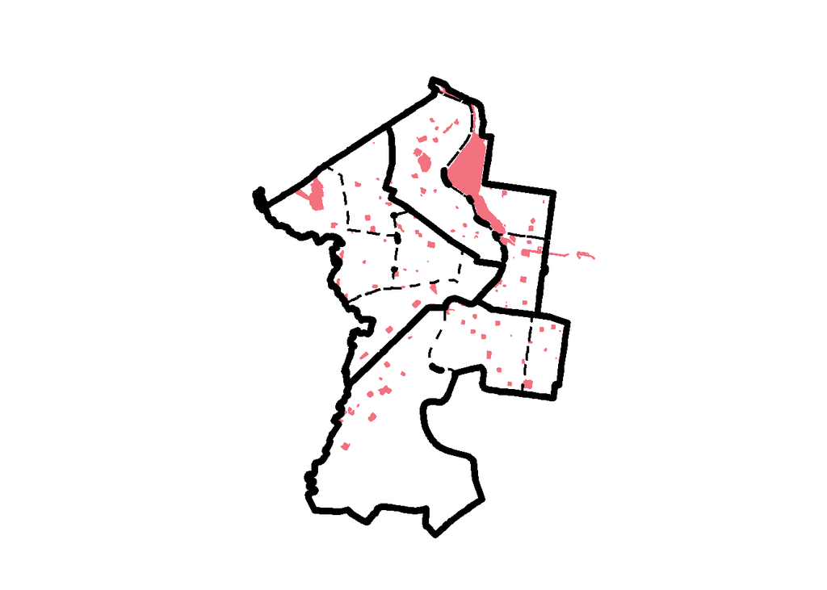

Figure. Locations of properties in District 7,8,9

```r
# map the location of properties in district 7,8,9
ggplot() +
  geom_sf(data=property %>% filter(Service.Area.PPR.District %in% c(7,8,9)),color=palette1_main,fill = palette1_main)+
  geom_sf(data=st_union(pprDestServiceArea %>% filter(PPR_DIST ==7)),color="black",size=2,fill = "transparent")+
  geom_sf(data=st_union(pprDestServiceArea %>% filter(PPR_DIST ==8)),color="black",size=2,fill = "transparent")+
  geom_sf(data=st_union(pprDestServiceArea %>% filter(PPR_DIST ==9)),color="black",size=2,fill = "transparent")+
  geom_sf(data=pprDestServiceArea,color="black",size=0.75,linetype ="dashed",fill = "transparent")+
  labs(title = "",
       subtitle = "",
       x="",y="")+
  mapTheme()
```

Through above wrangling, we obtain the newest data about property and link them with service areas. The map only map the properties in the district 7/8/9

#### Program data

```r
# define date
program2021.clean <- program2021 %>%
  mutate(AttendanceWeekDate = mdy(AttendanceWeekDate),
         DateFrom = mdy(DateFrom),
         DateTo = mdy(DateTo))

# create a df only containing records without program scheduel info
program2021.NA <- program2021.clean[is.na(program2021.clean$ProgramScheduleID),]

# filter by attendance date
program2021.clean <- program2021.clean %>%
  filter(AttendanceWeekDate > DateFrom & AttendanceWeekDate < DateTo)

# original data is recorded by week, here we change it into being recorded by occurence
program2021.clean <- separate(program2021.clean, Days,into= c("1","2","3","4","5","6","7"))
program2021.clean <- program2021.clean %>%
  gather(colNames, weekday, 15:21) %>%
  select(-colNames) %>%
  na.omit(cols='weekday')

# create exact attendance date
program2021.clean <- program2021.clean %>%
  mutate(AttendenceRealDate = case_when(
    weekday == "Monday" ~ AttendanceWeekDate,
    weekday == "Tuesday" ~ AttendanceWeekDate+1,
    weekday == "Wednesday" ~ AttendanceWeekDate+2,
    weekday == "Thursday" ~ AttendanceWeekDate+3,
    weekday == "Friday" ~ AttendanceWeekDate+4,
    weekday == "Saturday" ~ AttendanceWeekDate+5,
    weekday == "Sunday" ~ AttendanceWeekDate+6,
  ))
```

Through above wrangling, we obtain the real attendance date for each event. (p.s. a program may have more than one events which links with different program schedualed ids)

```r
propertyParent <- pprProperties %>%
  filter(NESTED=="N")

propertyKid <- pprProperties %>%
  filter(NESTED=="Y")
```

```r
program2021.join <- left_join(program2021.clean, facilityID, by =c("FacilityID")) %>%
  left_join(., pprProperties, by =c("PPR_Properties_ObjectID"="OBJECTID"))

# get the failed joining items
program2021.join.na <- program2021.join[is.na(program2021.join$PPR_Properties_ObjectID),]

# filter the failed joining items
program2021.join <- program2021.join %>% na.omit(PPR_Properties_ObjectID)
```

Through above wrangling, we link program data to their based properties.

#### SafeGraph Data

```r
# filter into philly
safeGraph <- patternAllMonth %>%
  filter(city == "Philadelphia")

# join with POI and brand data
safeGraph <- safeGraph %>%
  left_join(core_poi, by=c("placekey","parent_placekey","location_name","street_address","city","region","postal_code","safegraph_brand_ids","brands"),keep=FALSE) %>%
  left_join(brand_info, by=c("safegraph_brand_ids"="safegraph_brand_id","brands"="brand_name","top_category","sub_category","naics_code"),keep=FALSE)

# create geometry from lat & lng
safeGraph.geo <-
  safeGraph %>%
  st_as_sf(coords = c("longitude", "latitude"), crs = 4326, agr = "constant", na.fail=FALSE) %>% st_transform(crs = crs)
```

```r
## set future running stratege
library(furrr)
# change workers number by yourself
plan(multiprocess, workers = 10)
```

```r
# keep congeneric bussiness
congenericMoves <-
  safeGraph.geo %>%
  filter(top_category %in% c("Promoters of Performing Arts, Sports, and Similar Events",
                             "Other Amusement and Recreation Industries",
                             "Museums, Historical Sites, and Similar Institutions") | str_detect(location_name, "Park") | str_detect(location_name, "Playground") | str_detect(location_name, "Recreation Center")) %>%
  filter(str_detect(location_name, "Parking", negate = TRUE))


# Keep only ppr sites
#712190:Nature Parks and Other Similar Institutions;
#713990:All Other Amusement and Recreation Industries;
#713940: Fitness and Recreational Sports Centers；
#711310：Promoters of Performing Arts, Sports, and Similar Events
parks <- safeGraph.geo %>%
  dplyr::select(placekey, naics_code, location_name) %>%
  distinct() %>%
  filter(naics_code %in% c(712190, 713990, 713940, 711310) | str_detect(location_name, "Park") | str_detect(location_name, "Playground") | str_detect(location_name, "Recreation Center")) %>%
  filter(str_detect(location_name, "Parking", negate = TRUE))

PPRmoves <- safeGraph.geo %>%
  filter(placekey %in% as.list(parks$placekey))

#st_write(PPRmoves,"data/output/PPRmoves.GeoJSON")
PPRmoves <- st_read("data/output/PPRmoves.GeoJSON")
```

```
## replacing null geometries with empty geometries
## Simple feature collection with 11245 features and 44 fields (with 442 geometries empty)
## Geometry type: POINT
## Dimension:     XY
## Bounding box:  xmin: 2664598 ymin: 207698.2 xmax: 2749713 ymax: 303177.3
## Projected CRS: NAD83 / Pennsylvania South (ftUS)
```

```r
# spatial join with ppr sites - to be continued

# we need ask instructors which data to model, but for now just take PPRmoves
```

```r
# join filtered safeGraph place with ppr property
property_safe_join <- st_join(property, parks %>% dplyr::select(placekey, geometry), left=FALSE)

# count
print(paste0("The number of PPR properties is ", n_distinct(property$PPR.Site.Name)))
```

```
## [1] "The number of PPR properties is 370"
```

```r
print(paste0("The number joined properties is ", n_distinct(property_safe_join$PPR.Site.Name)))
```

```
## [1] "The number joined properties is 312"
```

```r
# the filtering quality is okay at this point, more data will be added
```

```r
#This following code to unnest the pupularity_by_hout data is different from the above code. Because the pprMoves is read into the R, which directly delete the '['']'

# unnest visit Count data
# visitCount <-
#   PPRmoves %>%
#   select(placekey, date_range_start, date_range_end, visits_by_day) %>%
#   mutate(date_range_start = as_date(date_range_start),
#          date_range_end = as_date(date_range_end)) %>%
#   dplyr::select(-date_range_end) %>%
#   mutate(visits_by_day = future_map(visits_by_day, function(x){
#     unlist(x) %>%
#       as_tibble() %>%
#       rowid_to_column(var = "day") %>%
#       mutate(visits = value) %>%
#       dplyr::select(-value)
#   })) %>%
#   unnest(cols = c("visits_by_day"))
#
# st_write(visitCount,"data/output/visitCount.GeoJSON")
visitCount <- st_read("data/output/visitCount.GeoJSON")
```

```
## replacing null geometries with empty geometries
## Simple feature collection with 341467 features and 4 fields (with 13418 geometries empty)
## Geometry type: POINT
## Dimension:     XY
## Bounding box:  xmin: 2664598 ymin: 207698.2 xmax: 2749713 ymax: 303177.3
## Projected CRS: NAD83 / Pennsylvania South (ftUS)
```

```r
# unnest popularity_by_hour data
visitHour <-
  PPRmoves %>%
  select(placekey, popularity_by_hour, date_range_start) %>%
  mutate(date_range_start = as_date(date_range_start),
         month =  month(date_range_start)) %>%
  dplyr::select(-date_range_start) %>%
  mutate(popularity_by_hour = future_map(popularity_by_hour, function(x){
    unlist(x) %>%
      as_tibble() %>%
      rowid_to_column(var = "hour") %>%
      rename(visit = value)
  }))%>%
  unnest(popularity_by_hour)
#
#st_write(visitHour,"data/output/visitHour.GeoJSON")
visitHour <- st_read("data/output/visitHour.GeoJSON")
```

```
## replacing null geometries with empty geometries
## Simple feature collection with 269880 features and 4 fields (with 10608 geometries empty)
## Geometry type: POINT
## Dimension:     XY
## Bounding box:  xmin: 2664598 ymin: 207698.2 xmax: 2749713 ymax: 303177.3
## Projected CRS: NAD83 / Pennsylvania South (ftUS)
```

```r
# unnest the origin-destination data

# originCount <-
#   PPRmoves %>%
#   select(placekey, visitor_home_cbgs, date_range_start) %>%
#   mutate(date_range_start = as_date(date_range_start),
#          month =  month(date_range_start)) %>%
#   dplyr::select(-date_range_start) %>%
#   mutate(visitor_home_cbgs = future_map(visitor_home_cbgs, function(x){
#     jsonlite::fromJSON(x) %>%
#       as_tibble()
#   })) %>%
#   unnest(visitor_home_cbgs)
#
# originCount <- originCount %>%
#   dplyr::select(placekey, month, starts_with("4")) %>%
#   pivot_longer(cols = starts_with("4"), names_to = "origin", values_to = "visits", values_drop_na = TRUE)

#st_write(originCount,"data/output/originCount.GeoJSON")
originCount <- st_read("data/output/originCount.GeoJSON")
```

```
## replacing null geometries with empty geometries
## Simple feature collection with 348460 features and 4 fields (with 12135 geometries empty)
## Geometry type: POINT
## Dimension:     XY
## Bounding box:  xmin: 2664598 ymin: 207698.2 xmax: 2749713 ymax: 303177.3
## Projected CRS: NAD83 / Pennsylvania South (ftUS)
```

```r
# The following codes is different from the above. Because I try to gather the data inside the tibble instead of the old way. This new way can greatly increase the efficiency.

# unnest the departure - destination data
# departCount <-
#   PPRmoves %>%
#   select(placekey, visitor_daytime_cbgs, date_range_start) %>%
#   mutate(date_range_start = as_date(date_range_start),
#          month =  month(date_range_start)) %>%
#   dplyr::select(-date_range_start) %>%
#   mutate(visitor_daytime_cbgs = future_map(visitor_daytime_cbgs, function(x){
#     jsonlite::fromJSON(x) %>%
#       as_tibble() %>%
#       dplyr::select(starts_with("4")) %>%
#       gather()
#   }))%>%
#   unnest(visitor_daytime_cbgs) %>%
#   rename(departure =key ,visitors= value)

#st_write(departCount,"data/output/departCount.GeoJSON")
departCount <- st_read("data/output/departCount.GeoJSON")
```

```
## replacing null geometries with empty geometries
## Simple feature collection with 299627 features and 4 fields (with 10555 geometries empty)
## Geometry type: POINT
## Dimension:     XY
## Bounding box:  xmin: 2664598 ymin: 207698.2 xmax: 2749713 ymax: 303177.3
## Projected CRS: NAD83 / Pennsylvania South (ftUS)
```

```r
# unnest the bucketed_dwell_times data
# dwellTime <-
#   PPRmoves %>%
#   select(placekey, bucketed_dwell_times, date_range_start) %>%
#   mutate(date_range_start = as_date(date_range_start),
#          month =  month(date_range_start)) %>%
#   dplyr::select(-date_range_start) %>%
#   mutate(bucketed_dwell_times = future_map(bucketed_dwell_times, function(x){
#     jsonlite::fromJSON(x) %>%
#       as_tibble() %>%
#       gather()
#   }))%>%
#   unnest(bucketed_dwell_times) %>%
#   rename(dwellTimes =key ,visitors= value)

#st_write(dwellTime,"data/output/dwellTime.GeoJSON")
dwellTime <- st_read("data/output/dwellTime.GeoJSON")
```

```
## replacing null geometries with empty geometries
## Simple feature collection with 78715 features and 4 fields (with 3094 geometries empty)
## Geometry type: POINT
## Dimension:     XY
## Bounding box:  xmin: 2664598 ymin: 207698.2 xmax: 2749713 ymax: 303177.3
## Projected CRS: NAD83 / Pennsylvania South (ftUS)
```

```r
# unnest the related_same_day_brand
# relatedBrand <-
#   PPRmoves %>%
#   select(placekey, related_same_day_brand, date_range_start) %>%
#   mutate(date_range_start = as_date(date_range_start),
#          month =  month(date_range_start)) %>%
#   dplyr::select(-date_range_start) %>%
#   mutate(related_same_day_brand = future_map(related_same_day_brand, function(x){
#     jsonlite::fromJSON(x) %>%
#       as_tibble() %>%
#       gather()
#   }))
#
# relatedBrand <- relatedBrand %>%
#   unnest(related_same_day_brand) %>%
#   rename(relatedBrand =key ,visitors= value)

#st_write(relatedBrand,"data/output/relatedBrand.GeoJSON")
relatedBrand <- st_read("data/output/relatedBrand.GeoJSON")
```

```
## replacing null geometries with empty geometries
## Simple feature collection with 209840 features and 4 fields (with 7592 geometries empty)
## Geometry type: POINT
## Dimension:     XY
## Bounding box:  xmin: 2664598 ymin: 207698.2 xmax: 2749713 ymax: 303177.3
## Projected CRS: NAD83 / Pennsylvania South (ftUS)
```

```r
# unnest the popularity_by_day data
# visitWeekday <-
#   PPRmoves %>%
#   select(placekey, popularity_by_day, date_range_start) %>%
#   mutate(date_range_start = as_date(date_range_start),
#          month =  month(date_range_start)) %>%
#   dplyr::select(-date_range_start) %>%
#   mutate(popularity_by_day = future_map(popularity_by_day, function(x){
#     jsonlite::fromJSON(x) %>%
#       as_tibble() %>%
#       gather()
#   }))%>%
#   unnest(popularity_by_day) %>%
#   rename(visitWeekday =key ,visits= value)
#
# st_write(visitWeekday,"data/output/visitWeekday.GeoJSON")
visitWeekday <- st_read("data/output/visitWeekday.GeoJSON")
```

```
## replacing null geometries with empty geometries
## Simple feature collection with 78715 features and 4 fields (with 3094 geometries empty)
## Geometry type: POINT
## Dimension:     XY
## Bounding box:  xmin: 2664598 ymin: 207698.2 xmax: 2749713 ymax: 303177.3
## Projected CRS: NAD83 / Pennsylvania South (ftUS)
```

```r
visitCount <- visitCount %>%
    rename(visitDay = date_range_start) %>%
    mutate(visitDay = day+visitDay-1) %>%
    mutate(month = month(visitDay))

# Problem: should the na geometry be dropped?
# join the location name of 'parks' into the unnested data
# visitCount2 <- visitCount %>%
#   left_join(parks %>% st_drop_geometry() ,by=c('placekey' = 'placekey'))
#
# test <- parks %>%
#   mutate(count=1) %>%
#   group_by(placekey) %>%
#   mutate(location_name = location_name,count=sum(count)) %>%
#   filter(count == 2)
```

### EXPLORATORY – CENSUS DATA

## 1. Get each of the Philadelphia PPR zones

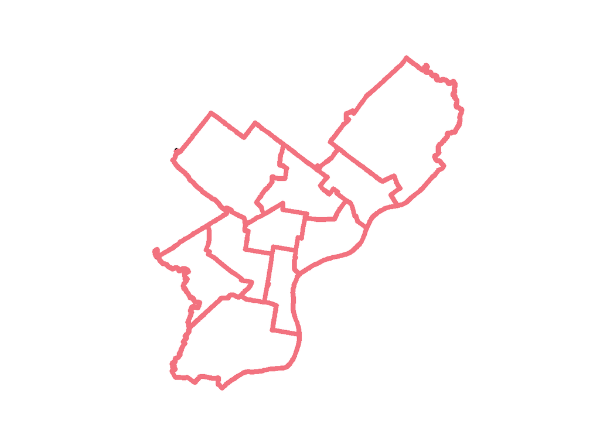

```r
ggplot() +
  geom_sf(data=ll(st_union(pprDistrict)),color="black",size=2,fill = "transparent",inherit.aes = FALSE)+
  geom_sf(data=ll(pprDistrict),color=palette1_main,size=2,fill = "transparent",inherit.aes = FALSE)+
  labs(title = "",
       subtitle = "",
       x="",y="")+
  mapTheme()
```

## 2. Get the list of PHL census tracts that intersect with each zone

```r
acs_vars <- c("B25026_001E","B02001_002E","B15001_050E",
                         "B15001_009E","B19013_001E","B25058_001E",
                         "B06012_002E", "B01001_048E", "B01001_049E",
                         "B01001_024E", "B01001_025E", "B07013_002E")

tracts19 <-
    get_acs(geography = "tract",
            variables = acs_vars,
            year=2019,
            state='PA',
            county='Philadelphia',
            geometry=T,
            output="wide") %>%
        st_transform(crs) %>%
        dplyr::rename(TotalPop = B25026_001E,
               White = B02001_002E,
               MedianHouseholdIncome = B19013_001E,
               MedianRent = B25058_001E,
               Poverty = B06012_002E,
               HousingUnits = B07013_002E) %>%
        dplyr::select(-NAME, -starts_with("B")) %>%
        mutate(pctNonWhite = ifelse(TotalPop < White, 0, ifelse(TotalPop > 0, 1 -(White / TotalPop),0)),
               pctPoverty = ifelse(TotalPop > 0, Poverty / TotalPop, 0))
## joined
tracts19_pprArea <- tracts19 %>%
                    st_join(pprDistrict, join=st_intersects)

tracts19_grouped_summary <- tracts19_pprArea %>%
      dplyr::select(TotalPop, MedianHouseholdIncome, MedianRent, HousingUnits, pctNonWhite, pctPoverty, DISTRICTID, geometry) %>%
      dplyr::group_by(DISTRICTID) %>%
      summarize(TotalPop_sum= sum(TotalPop),
                MedianHouseholdIncome_mean = mean(MedianHouseholdIncome, na.rm=TRUE),
                MedianRent_mean = mean(MedianRent, na.rm=TRUE),
                HousingUnits_sum = sum(HousingUnits, na.rm=TRUE),
                pctNonWhite_mean = mean(pctNonWhite),
                pctPoverty_mean = mean(pctPoverty)
      )
```

```r
# ggplot(PPRmoves)+
#   geom_line(aes(x = date_range_start, y = raw_visit_counts))+
#   facet_wrap(~location_name, scales = "free")
```

### Loading Data into Database

```r
library(RPostgres)

conn <- dbConnect(Postgres(), dbname = dbname, host = host, port = port,
                  user = username, password = password)


# to lowercase and replace invalid character with "_"
s <- tracts19_grouped_summary %>%
  rename_all(tolower) %>%
  rename_all({function (t) str_replace_all(t,"[^\\w]","_")})

st_write(obj = s, dsn = conn, Id(table = "census_summary"))
```

```
## Note: method with signature 'DBIObject#sf' chosen for function 'dbDataType',
##  target signature 'PqConnection#sf'.
##  "PqConnection#ANY" would also be valid
```

```r
# writing to postgres
# dbListTables(conn)
```

```r
# print(pprTrails)
```

```r
library(RPostgres)

conn <- dbConnect(Postgres(), dbname = dbname, host = host, port = port,
                  user = username, password = password)


# to lowercase and replace invalid character with "_"
s <- tracts19_grouped_summary %>%
  rename_all(tolower) %>%
  rename_all({function (t) str_replace_all(t,"[^\\w]","_")})

st_write(obj = s, dsn = conn, Id(table = "census_summary"))
# writing to postgres
# dbListTables(conn)
```

### EXPLORATORY – SafeGrpah DATA

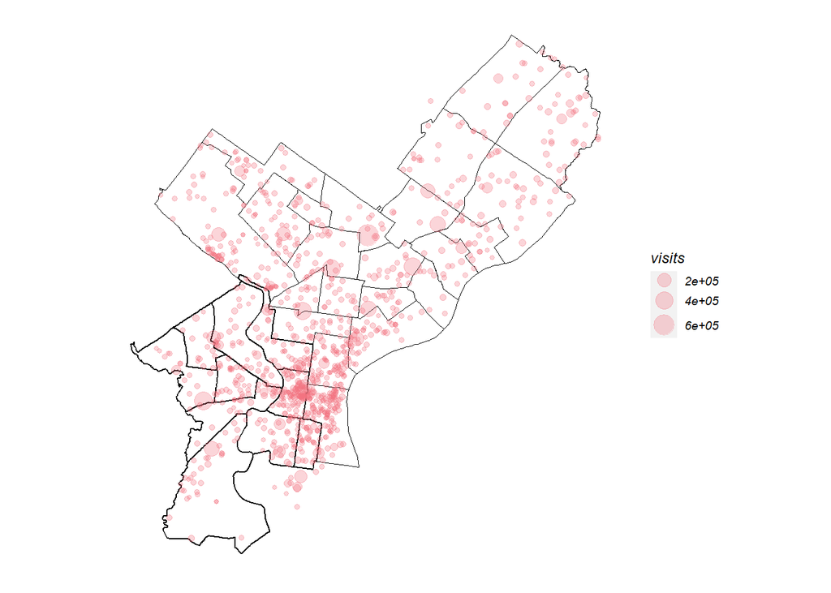

```r
sumVisit <- visitCount %>%
  dplyr::select(-visitDay,-day,-month) %>%
  group_by(placekey) %>%
  summarise(visits=sum(visits))

ggplot(sumVisit)+
  geom_sf(data=pprServiceArea,color='black',size=0.25,fill= "transparent")+
  geom_sf(data=pprServiceArea %>% filter(PPR_DIST %in% c(7,8,9)),color='black',size=0.5,fill= "transparent")+
  geom_sf(aes(size = visits),color = palette1_main,fill = palette1_main,alpha = 0.3) +
  mapTheme()
```

The above is the aggragated visits map of PPR sities. The data is from safegraph.

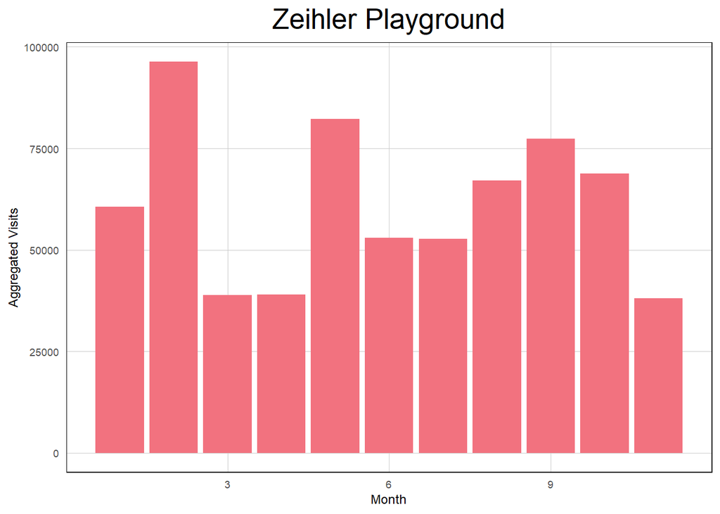

```r
sumVisit <- visitCount %>%
  filter(placekey=='zzz-222@628-pj6-ndv') %>%
  dplyr::select(-visitDay,-day) %>%
  group_by(month) %>%
  summarise(visits=sum(visits)) %>%
  st_drop_geometry()

sumVisit%>%
  ggplot(aes(month,visits)) +
  geom_bar(position ="dodge",fill = palette1_main,stat='identity') +
  labs(x="Month", y="Aggregated Visits",
       title ='Zeihler Playground') +
  plotTheme(10,20)
```

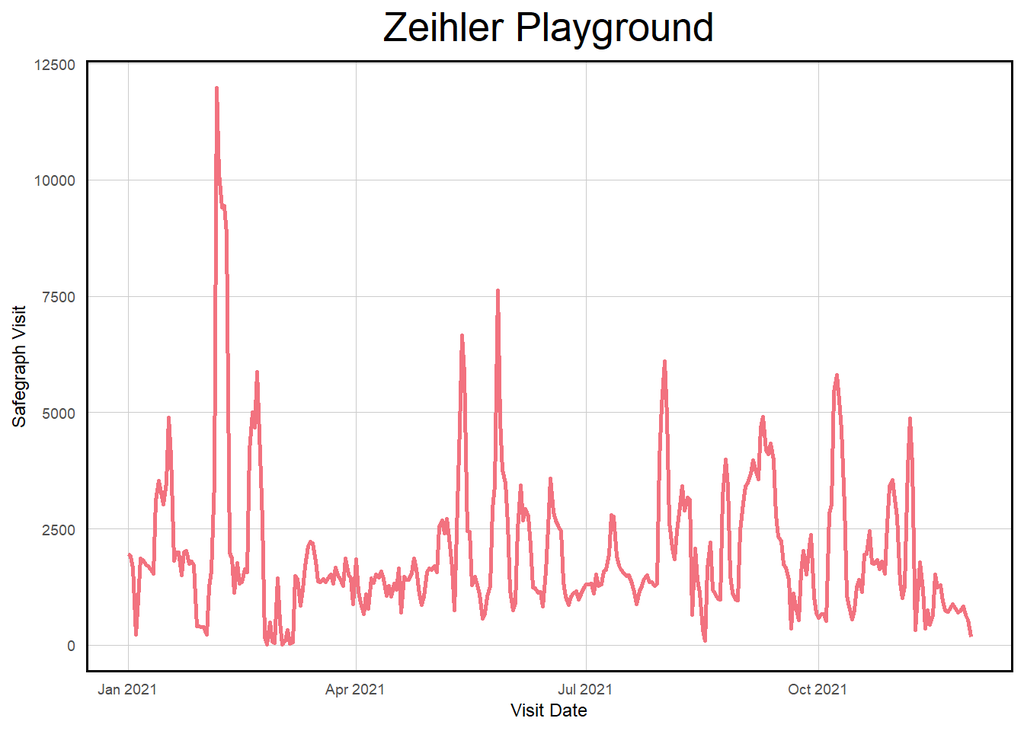

```r
visitCount %>%
  filter(placekey=='zzz-222@628-pj6-ndv') %>%
  st_drop_geometry()%>%
  na.omit()%>%
  ggplot(aes(visitDay,visits)) +
  geom_line(color=palette1_main,size=1)+
  labs(title = 'Zeihler Playground',x="Visit Date",y="Safegraph Visit")+
  plotTheme(10,20)+
  theme(panel.border = element_rect(colour = "black", fill=NA, size=1))
```

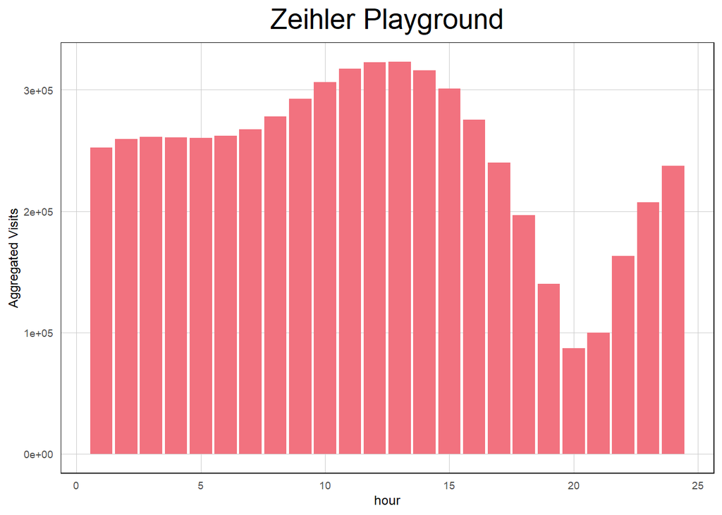

```r
sumVisit <- visitHour %>%
  filter(placekey=='zzz-222@628-pj6-ndv') %>%
  dplyr::select(-month) %>%
  group_by(hour) %>%
  summarise(visits=sum(visit)) %>%
  st_drop_geometry()

sumVisit%>%
  ggplot(aes(hour,visits)) +
  geom_bar(position ="dodge",fill = palette1_main,stat='identity') +
  labs(x="hour", y="Aggregated Visits",
       title ='Zeihler Playground') +
  plotTheme(10,20)
```

```r
sumVisit <- visitWeekday %>%
  filter(placekey=='zzz-222@628-pj6-ndv') %>%
  dplyr::select(-month) %>%
  group_by(visitWeekday) %>%
  summarise(visits=sum(visits)) %>%
  st_drop_geometry()

sumVisit$visitWeekday <- factor(sumVisit$visitWeekday, levels= c("Monday",
    "Tuesday", "Wednesday", "Thursday", "Friday", "Saturday","Sunday"))

sumVisit[order(sumVisit$visitWeekday), ]
```

```
## # A tibble: 7 x 2
##   visitWeekday visits
##   <fct>         <int>
## 1 Monday        88417
## 2 Tuesday       90427
## 3 Wednesday     84327
## 4 Thursday      95314
## 5 Friday       106913
## 6 Saturday     104538
## 7 Sunday       104340
```

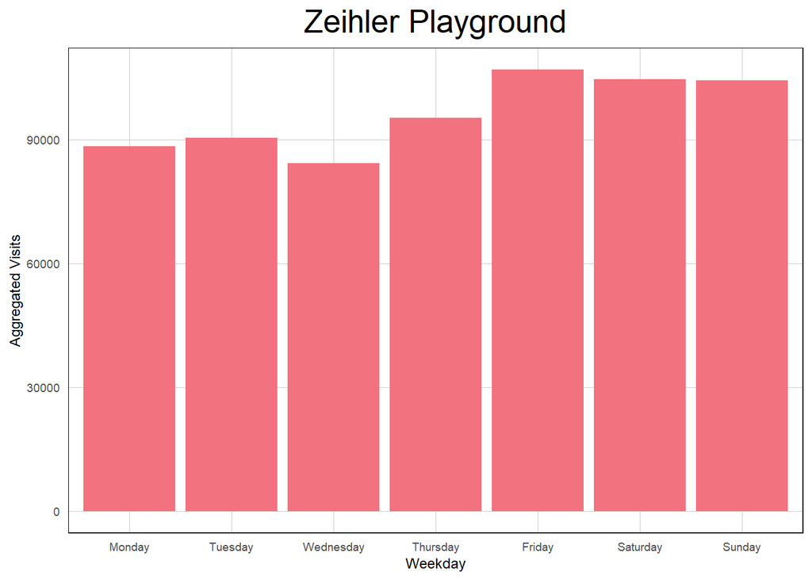

```r
sumVisit%>%
  ggplot(aes(visitWeekday,visits)) +
  geom_bar(position ="dodge",fill = palette1_main,stat='identity') +
  labs(x="Weekday", y="Aggregated Visits",
       title ='Zeihler Playground') +
  plotTheme(10,20)
```

```r
sumVisit <- dwellTime %>%
  filter(placekey=='zzz-222@628-pj6-ndv') %>%
  dplyr::select(-month) %>%
  group_by(dwellTimes) %>%
  summarise(visitors=sum(visitors)) %>%
  st_drop_geometry()

sumVisit$dwellTimes <- factor(sumVisit$dwellTimes, levels= c("<5",">240","11-20","121-240","21-60","5-10","61-120" ))

sumVisit[order(sumVisit$dwellTimes), ]
```

```
## # A tibble: 7 x 2
##   dwellTimes visitors
##   <fct>         <int>
## 1 <5              440
## 2 >240         392586
## 3 11-20          6347
## 4 121-240      126971
## 5 21-60         49257
## 6 5-10           4128
## 7 61-120        94547
```

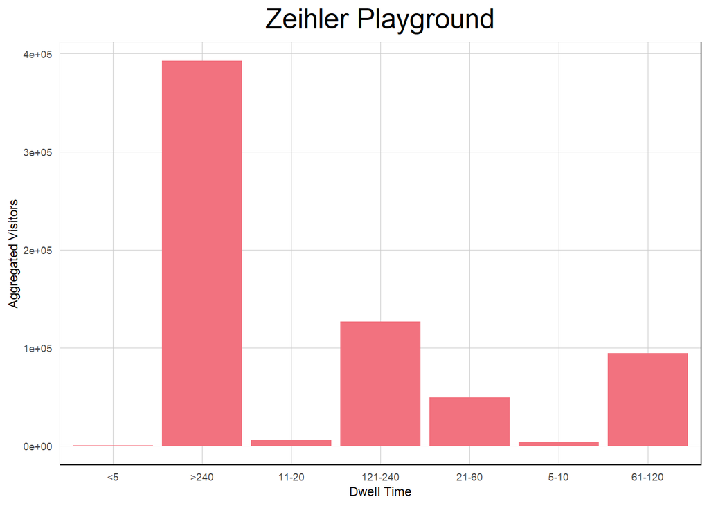

```r
sumVisit%>%
  ggplot(aes(dwellTimes,visitors)) +
  geom_bar(position ="dodge",fill = palette1_main,stat='identity') +
  labs(x="Dwell Time", y="Aggregated Visitors",
       title ='Zeihler Playground') +
  plotTheme(10,20)
```